# Tidyverse

Pablo Andrés Guzmán Taller R y Rmarkdown

Ago 2023

El **tidyverse** es una colección de paquetes diseñados para *data science* y que comparten un modo de trabajo similar.

[figure not shown]

Figure 1: Página web del tidyverse: https://www.tidyverse.org/

En este recurso aprenderemos el uso de dos comandos del paquete **tidyr**: `pivot_wider` y `pivot_longer`. Para activar los paquetes del **tidyverse** (incluyendo **tidyr**) use el siguiente código:

```r
library(tidyverse)  # activando paquetes del tidyverse (dplyr, ggplot2, tidyr, etc.)
```

## Operador “pipe” (`%>%` ó `|>`)

Este operador permite pasar el objeto que esta a su izquierda como **primer** argumento del comando que está a su derecha, y con esto, favorece la escritura de código donde se deben usar varios comandos, uno detras de otro, para transformar un objeto.

El operador `%>%` (ó `|>`) pasa el objeto a su izquierda como primer argumento del comando a su derecha. Es decir, el código:

`f(x,y)`

es equivalente a

`x %>% f(y)`

`x |> f(y)`

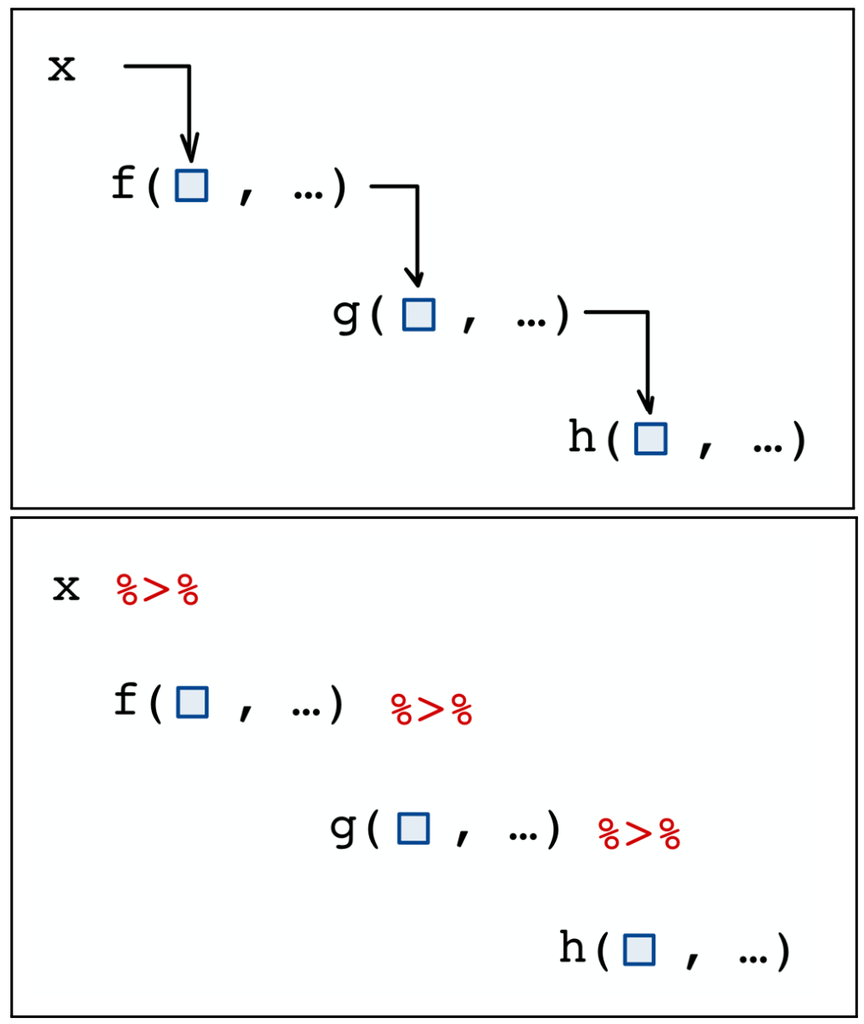

## Formatos ancho y largo

Considere las siguientes dos tablas como ejemplos de formatos ancho (izquierda) y largo (derecha):

```r
datw  # ANCHO
```

```
# A tibble: 6 × 5
     id g        y1    y2    y3
  <int> <chr> <int> <dbl> <dbl>
1     1 b        15  15.9 18.3
2     2 c         5   5.3  6.10
3     3 a        16  17.0 19.5
4     4 a        19  20.1 23.2
5     5 b        12  12.7 14.6
6     6 a        14  14.8 17.1
```

```r
datl  # LARGO
```

```
# A tibble: 18 × 4
      id g     y     value
   <int> <chr> <chr> <dbl>
 1     1 b     y1    15
 2     1 b     y2    15.9
 3     1 b     y3    18.3
 4     2 c     y1     5
 5     2 c     y2     5.3
 6     2 c     y3     6.10
 7     3 a     y1    16
 8     3 a     y2    17.0
 9     3 a     y3    19.5
10     4 a     y1    19
11     4 a     y2    20.1
12     4 a     y3    23.2
13     5 b     y1    12
14     5 b     y2    12.7
15     5 b     y3    14.6
16     6 a     y1    14
17     6 a     y2    14.8
18     6 a     y3    17.1
```

**Ejemplo 1: Ancho a largo**

Considere la siguiente tabla y escribala (a mano) en su cuaderno en formato largo para las columnas `m` y `h`

| m | h |
| --- | --- |
| 3.0 | 10.5 |
| 3.5 | 11.0 |
| 2.0 | 12.0 |

**Ejemplo 2: largo a ancho**

Considere la siguiente tabla. Escriba (a mano) en su cuaderno una nueva tabla donde separe los valores de `z` en varias columnas de acuerdo a la columna `x`:

| i | x | z |
| --- | --- | --- |
| 1 | a | 3.0 |
| 2 | a | 3.5 |
| 1 | b | 2.0 |
| 2 | b | 10.0 |

Son múltiples los escenarios en los cuales necesitamos pasar los datos desde una organización a otra y los comandos `pivot_wider` y `pivot_longer` (paquete **tidyr**) permiten cambiar esta organización desde uno a otro formato. A continuación mostramos el uso de cada comando. Para esto descargue las tablas de ejemplo presentadas arriba y prepare su script de **R** como sigue:

```r
library(tidyverse)    # active el tidyverse
rm(list = ls())       # Borre todo su ambiente de trabajo

# Cargue los datos
load('datwl.RData')   # el archivo 'datwl.RData' debe estar en su directorio de trabajo
ls()                  # imprima los nombres de los objetos cargados

# Imprima las tablas para conocer su contenido
datw    # ancho
datl    # largo
```

## `pivot_wider`

Este comando recibe los datos en formato largo y los entrega en formato ancho. Cuenta con tres argumentos principales cuyo uso se muestra en seguida:

```r
# Ejemplo de uso del comando pivot_wider ----
pivot_wider(
  data        = datl,   # data.frame en formato largo

  # columna desde donde tomaremos los nombres de las nuevas columnas
  names_from  = 'y',

  # columna desde donde tomaremos los valores para llenar las nuevas columnas
  values_from = 'value'
)
```

```
# A tibble: 6 × 5
     id g        y1    y2    y3
  <int> <chr> <dbl> <dbl> <dbl>
1     1 b        15  15.9 18.3
2     2 c         5   5.3  6.10
3     3 a        16  17.0 19.5
4     4 a        19  20.1 23.2
5     5 b        12  12.7 14.6
6     6 a        14  14.8 17.1
```

## `pivot_longer`

Este comando recibe los datos en formato ancho y los entrega en formato largo. Cuenta con cuatro argumentos principales cuyo uso se muestra en seguida:

```r
# Ejemplo de uso del comando pivot_longer ----
pivot_longer(
  data = datw,    # datos en formato ancho

  # Columnas de data que seran cambiadas a formato largo
  cols = y1:y3,

  # ¿Como se quiere llamar la nueva columna indicadora?
  names_to = 'y',

  # ¿Como se quiere llamar la nueva columna que tendra los valores?
  values_to = 'value'
  )
```

```
# A tibble: 18 × 4
      id g     y     value
   <int> <chr> <chr> <dbl>
 1     1 b     y1    15
 2     1 b     y2    15.9
 3     1 b     y3    18.3
 4     2 c     y1     5
 5     2 c     y2     5.3
 6     2 c     y3     6.10
 7     3 a     y1    16
 8     3 a     y2    17.0
 9     3 a     y3    19.5
10     4 a     y1    19
11     4 a     y2    20.1
12     4 a     y3    23.2
13     5 b     y1    12
14     5 b     y2    12.7
15     5 b     y3    14.6
16     6 a     y1    14
17     6 a     y2    14.8
18     6 a     y3    17.1
```

Un aspecto que permite validar, al menos parcialmente, el `pivot` a formato largo es que el número de filas de la nueva tabla en formato largo debe ser igual al producto de la cantidad de filas de la tabla en formato ancho por el número de variables a “pivotear”. Para el ejemplo de arriba, la tabla en formato ancho tiene 6 filas y se “pivotearon” 3 columnas (`y1`, `y2` y `y3`), luego, la nueva tabla en formato largo debe tener 6 x 3 = 18 filas totales.

## Ejercicios

### Ej. 1: Datos longitudinales

Los datos `carData::WeightLoss` presentan la perdida de peso y una valoración de autoestima para 34 sujetos en tres tratamientos (`Control`, `Diet` y `DietEx`) durante tres meses.

```r
library(carData)
?WeightLoss   # para solicitar ayuda sobre los datos
dat <- WeightLoss
dat <- mutate(WeightLoss, group = factor(group))
str(dat)
```

```
'data.frame':   34 obs. of  7 variables:
 $ group: Factor w/ 3 levels "Control","Diet",..: 1 1 1 1 1 1 1 1 1 1 ...
 $ wl1  : int  4 4 4 3 5 6 6 5 5 3 ...
 $ wl2  : int  3 4 3 2 3 5 5 4 4 3 ...
 $ wl3  : int  3 3 1 1 2 4 4 1 1 2 ...
 $ se1  : int  14 13 17 11 16 17 17 13 14 14 ...
 $ se2  : int  13 14 12 11 15 18 16 15 14 15 ...
 $ se3  : int  15 17 16 12 14 18 19 15 15 13 ...
```

Convierta los datos en formato largo “pivoteando” las columnas `wl1`, `wl2` y `wl3`. La tabla debe quedar como se muestra a continuación:

```
# A tibble: 102 × 7
      id group     se1   se2   se3 month    wl
   <int> <fct>   <int> <int> <int> <dbl> <int>
 1     1 Control    14    13    15     1     4
 2     1 Control    14    13    15     2     3
 3     1 Control    14    13    15     3     3
 4     2 Control    13    14    17     1     4
 5     2 Control    13    14    17     2     4
 6     2 Control    13    14    17     3     3
 7     3 Control    17    12    16     1     4
 8     3 Control    17    12    16     2     3
 9     3 Control    17    12    16     3     1
10     4 Control    11    11    12     1     3
# ℹ 92 more rows
```

**Código solución**

```r
datl <- dat %>%
  mutate(
    id = 1:n(),
  ) %>%
  relocate(id, .before = group) %>%
  pivot_longer(cols = wl1:wl3, names_to = 'month', values_to = 'wl',
             names_prefix = 'wl') %>%
  mutate(month = as.numeric(month))
datl
```

### Ej. 2: Datos longitudinales, dos variables

En el contexto de los datos del ejercicio anterior considere que se registraron dos variables respuestas para cada sujeto, la perdida de peso (`wl1`, `wl2` y `wl3`) pero también un puntaje de autoestima (`se1`, `se2` y `se3`). Pase los datos a formato largo de tal forma que la nueva tabla se vea como sigue:

```
# A tibble: 102 × 5
      id group   month    wl    se
   <int> <fct>   <dbl> <int> <int>
 1     1 Control     1     4    14
 2     1 Control     2     3    13
 3     1 Control     3     3    15
 4     2 Control     1     4    13
 5     2 Control     2     4    14
 6     2 Control     3     3    17
 7     3 Control     1     4    17
 8     3 Control     2     3    12
 9     3 Control     3     1    16
10     4 Control     1     3    11
# ℹ 92 more rows
```

Para lograr esto, considere los siguientes pasos:

1. Aplique `mutate` para agregar una nueva columna `id` con un identificador único para cada sujeto. Utilice `relocate` para lograr que esta columna `id` quede de primero.
2. Aplique `pivot_longer` para “pivotear” las columnas `wl1`, `wl2`, `wl3`, `se1`, `se2` y `se3` a una única columna de valores.
3. Utilice `mutate` con el comando `substr` para separar la columna indicadora en dos nuevas columnas, una que contenga sólo los nombres de las variables (`wl` y `se`) y otra que contenga sólo el mes (`1`, `2` y `3`). Remueva la columna indicadora con `select`.
4. Aplique `pivot_wider` para pasar a formato ancho la columna de valores separandola en dos nuevas columnas, una con los valores de `wl` y otra con los de `se`.

**Código solución**

```r
datl2 <- dat %>%
  mutate(
    id = 1:n(),
  ) %>%
  relocate(id, .before = group) %>%
  pivot_longer(cols = wl1:se3, names_to = 'var_month', values_to = 'value') %>%
  mutate(
    var   = substr(var_month, 1,2),
    month = as.numeric(substr(var_month, 3,3))
  ) %>%
  select(-var_month) %>%
  pivot_wider(
    names_from = 'var',
    values_from = 'value'
  )
datl2
```

### Ej. 3: Estadísticos descriptivos

La tabla `gestStats` presenta algunos estadísticos descriptivos del peso al nacimiento por la edad y por el estatus de fumar de la madre generados desde la base de datos `mosaicData::Gestation`.

```r
load('gestStats.RData')  # el archivo 'gestStats.RData' debe estar en el dir. de trabajo
gestStats   # imprima la tabla
```

```
# A tibble: 16 × 5
   age   smoke     n stat  stat_value
   <fct> <chr> <int> <chr>      <dbl>
 1 15-28 no      460 min         62
 2 15-28 no      460 max        176
 3 15-28 no      460 mean       123.
 4 15-28 no      460 sd          16.1
 5 15-28 yes     317 min         65
 6 15-28 yes     317 max        163
 7 15-28 yes     317 mean       114.
 8 15-28 yes     317 sd          17.4
 9 28-45 no      281 min         55
10 28-45 no      281 max        174
11 28-45 no      281 mean       123.
12 28-45 no      281 sd          19.4
13 28-45 yes     166 min         58
14 28-45 yes     166 max        160
15 28-45 yes     166 mean       113.
16 28-45 yes     166 sd          19.5
```

Observe que el valor de los estadísticos se encuentra en una sóla columna lo que dificulta la lectura de la información. Convierta la tabla `gestStats` a formato ancho de tal forma que la nueva tabla se vea como sigue:

```
# A tibble: 4 × 7
  age   smoke     n   min   max  mean    sd
  <fct> <chr> <int> <dbl> <dbl> <dbl> <dbl>
1 15-28 no      460    62   176  123.  16.1
2 15-28 yes     317    65   163  114.  17.4
3 28-45 no      281    55   174  123.  19.4
4 28-45 yes     166    58   160  113.  19.5
```

## Para saber más

### Largo a ancho con sólo dos columnas

Considere las siguientes dos tablas:

```r
d1 <- tibble(
  x = c('a', 'a', 'b', 'b'),
  z = c(3, 3.5, 2, 10)
)
d1
```

```
# A tibble: 4 × 2
  x         z
  <chr> <dbl>
1 a       3
2 a       3.5
3 b       2
4 b      10
```

```r
d2 <- tibble(
  i = c(1,2,1,2),
  x = c('a', 'a', 'b', 'b'),
  z = c(3, 3.5, 2, 10)
)
d2
```

```
# A tibble: 4 × 3
      i x         z
  <dbl> <chr> <dbl>
1     1 a       3
2     2 a       3.5
3     1 b       2
4     2 b      10
```

Suponga que se quiere “pivotear” la columna `z` a nuevas columnas de acuerdo a los nombres de la columna `x`. El comando `pivot_wider` no funciona desde la tabla `d1` pero si desde la tabla `d2`, observe:

```r
pivot_wider(d1, names_from = x, values_from = z)
```

```
# A tibble: 1 × 2
  a         b
  <list>    <list>
1 <dbl [2]> <dbl [2]>
```

```r
pivot_wider(d2, names_from = x, values_from = z)
```

```
# A tibble: 2 × 3
      i     a     b
  <dbl> <dbl> <dbl>
1     1   3       2
2     2   3.5    10
```

### NA’s

Cuando se va a pasar de formato largo a ancho, es importante considerar la columna que indica a los sujetos. Considere estos dos ejemplos similares, pero difieren en que en `d1` hay tres filas pero dos sujetos, mientras que en `d1` hay tres filas y tres sujetos. Observe que se agregan NA en los espacios perdidos:

```r
d1 <- tibble(
  i = c(1,2,1),
  x = c('a', 'a', 'b'),
  z = c(3, 3.5, 2)
)
d1
```

```
# A tibble: 3 × 3
      i x         z
  <dbl> <chr> <dbl>
1     1 a       3
2     2 a       3.5
3     1 b       2
```

```r
pivot_wider(d1, names_from = x, values_from = z)
```

```
# A tibble: 2 × 3
      i     a     b
  <dbl> <dbl> <dbl>
1     1   3       2
2     2   3.5    NA
```

```r
d2 <- tibble(
  i = c(1,2,3),
  x = c('a', 'a', 'b'),
  z = c(3, 3.5, 2)
)
d2
```

```
# A tibble: 3 × 3
      i x         z
  <dbl> <chr> <dbl>
1     1 a       3
2     2 a       3.5
3     3 b       2
```

```r
pivot_wider(d2, names_from = x, values_from = z)
```

```
# A tibble: 3 × 3
      i     a     b
  <dbl> <dbl> <dbl>
1     1   3      NA
2     2   3.5    NA
3     3  NA       2
```